# realtion between accidents and types

```python
import pandas as pd

# Load the data
file_path = 'Rawalpindi.xlsx'
sheet_name = 'accident types'
df = pd.read_excel(file_path, sheet_name=sheet_name)
```

```python
import statsmodels.api as sm

# Define the dependent and independent variables
X = df[['Derailments', 'Collisions', 'Collisions at LC']]
y = df['No of Accidents']

# Add a constant to the model (intercept)
X = sm.add_constant(X)

# Fit the GLM model
glm_poisson = sm.GLM(y, X, family=sm.families.Poisson()).fit()

# Get the summary of the model
summary = glm_poisson.summary()
print(summary)
```

```
                 Generalized Linear Model Regression Results
==============================================================================
Dep. Variable:        No of Accidents   No. Observations:                    6
Model:                            GLM   Df Residuals:                        2
Model Family:                 Poisson   Df Model:                            3
Link Function:                    Log   Scale:                          1.0000
Method:                          IRLS   Log-Likelihood:                -12.784
Date:                Wed, 31 Jul 2024   Deviance:                     0.083405
Time:                        19:56:07   Pearson chi2:                   0.0829
No. Iterations:                     4   Pseudo R-squ. (CS):             0.9601
Covariance Type:            nonrobust
====================================================================================
                       coef    std err          z      P>|z|      [0.025      0.975]
------------------------------------------------------------------------------------
const                1.3779      0.377      3.657      0.000       0.639       2.116
Derailments          0.0771      0.061      1.272      0.203      -0.042       0.196
Collisions          -0.0303      0.142     -0.213      0.831      -0.309       0.248
Collisions at LC     0.1254      0.070      1.782      0.075      -0.013       0.263
====================================================================================
```

## interpretation

Interpretation of Rawalpindi Area Model Model Overview

This model explores the relationship between different types of accidents (derailments, collisions, and collisions at level crossings) and the overall number of accidents in the Rawalpindi area. It uses a Poisson regression model, suitable for count data, with a log link function. The Pseudo R-squared value of 0.9601 indicates that the model explains approximately 96% of the variance in the number of accidents, suggesting a very good fit.

Model Parameters

Intercept (constant): The coefficient for the intercept is 1.3779, indicating the expected log count of accidents when all other variables are zero. The intercept is highly significant, with a z-value of 3.657 and a p-value less than 0.001.

Derailments: The coefficient for derailments is 0.0771, which suggests a positive relationship with the number of accidents. However, this relationship is not statistically significant (p = 0.203), indicating that derailments do not have a strong impact on the overall number of accidents in this model.

Collisions: The coefficient for collisions is -0.0303, suggesting a negative relationship with the number of accidents. This relationship is also not statistically significant (p = 0.831), indicating that collisions do not significantly impact the overall number of accidents in this model.

Collisions at Level Crossings (LC): The coefficient for collisions at LC is 0.1254, indicating a positive relationship with the number of accidents. This relationship is marginally significant (p = 0.075), suggesting that collisions at level crossings may have some impact on the overall number of accidents.

Intercept: The high and significant intercept value suggests a baseline level of accidents even when other factors are not considered. Derailments: While there is a positive coefficient, derailments do not significantly impact the total number of accidents in this model. Collisions: The negative coefficient for collisions suggests a slight decrease in total accidents, but this effect is not statistically significant. Collisions at LC: There is a positive relationship with the total number of accidents, and this factor is marginally significant, indicating a potential area for further investigation or mitigation efforts.

### Key Takeaways

- **Intercept**: The high and statistically significant intercept (1.3779) suggests a substantial baseline level of accidents in the Rawalpindi area, even when other factors are not considered.
- **Derailments**: Although the coefficient for derailments is positive (0.0771), it is not statistically significant (p = 0.203). This indicates that derailments do not have a strong impact on the total number of accidents in this model.
- **Collisions**: The negative coefficient for collisions (-0.0303) suggests a slight decrease in the total number of accidents. However, this effect is not statistically significant (p = 0.831), indicating that collisions do not significantly influence the overall number of accidents.
- **Collisions at Level Crossings (LC)**: The positive coefficient for collisions at level crossings (0.1254) is marginally significant (p = 0.075). This suggests that collisions at level crossings may contribute to the total number of accidents, warranting further investigation or targeted safety measures.

#### Conclusion

The model demonstrates an excellent fit with a Pseudo R-squared value of 0.9601, indicating it explains approximately 96% of the variance in accident counts. While derailments and collisions do not show a significant impact on the overall number of accidents, collisions at level crossings could be a potential area for intervention. The substantial baseline level of accidents, as indicated by the high intercept, highlights the need for ongoing safety efforts.

# Location

```python
import pandas as pd
import statsmodels.api as sm
from statsmodels.formula.api import glm

# Load the data
file_path = 'Rawalpindi.xlsx'
sheet_name = 'Location of Accidents'
df = pd.read_excel(file_path, sheet_name=sheet_name)

# Replace spaces in column names with underscores
df.columns = df.columns.str.replace(' ', '_')


# Fit the GLM excluding the 'Year' variable
model = glm('No_of_Accidents ~ Accidents_at_Track + Accidents_in_Station_Limits',
            data=df,
            family=sm.families.Poisson()).fit()

# Print the summary of the model
print(model.summary())
```

```
                 Generalized Linear Model Regression Results
==============================================================================
Dep. Variable:        No_of_Accidents   No. Observations:                    6
Model:                            GLM   Df Residuals:                        3
Model Family:                 Poisson   Df Model:                            2
Link Function:                    Log   Scale:                          1.0000
Method:                          IRLS   Log-Likelihood:                -13.089
Date:                Wed, 31 Jul 2024   Deviance:                      0.69453
Time:                        19:58:13   Pearson chi2:                    0.673
No. Iterations:                     4   Pseudo R-squ. (CS):             0.9558
Covariance Type:            nonrobust
===============================================================================================
                                  coef    std err          z      P>|z|      [0.025      0.975]
-----------------------------------------------------------------------------------------------
Intercept                       1.5075      0.302      4.990      0.000       0.915       2.100
Accidents_at_Track              0.0729      0.043      1.690      0.091      -0.012       0.157
Accidents_in_Station_Limits     0.0710      0.059      1.208      0.227      -0.044       0.186
===============================================================================================
```

## interpretation

This model examines the relationship between accidents occurring at tracks and in station limits and the overall number of accidents in the Rawalpindi area. The Poisson regression model with a log link function is appropriate for this count data. The Pseudo R-squared value of 0.9558 indicates that the model explains approximately 95.58% of the variance in the number of accidents, suggesting a very good fit.

Model Parameters

Intercept (constant): The coefficient for the intercept is 1.5075, indicating the expected log count of accidents when all other variables are zero. The intercept is highly significant, with a z-value of 4.990 and a p-value less than 0.001.

Accidents at Track: The coefficient for accidents at track is 0.0729, suggesting a positive relationship with the number of accidents. This relationship is marginally significant (p = 0.091), indicating that accidents at track may have some impact on the overall number of accidents.

Accidents in Station Limits: The coefficient for accidents in station limits is 0.0710, indicating a positive relationship with the number of accidents. This relationship is not statistically significant (p = 0.227), suggesting that accidents in station limits do not have a strong impact on the overall number of accidents in this model.

# Type of Line

```python
import pandas as pd
import statsmodels.api as sm
from statsmodels.formula.api import glm

# Load the data
file_path = 'Rawalpindi.xlsx'
sheet_name = 'type of line'
df = pd.read_excel(file_path, sheet_name=sheet_name)

# Replace spaces in column names with underscores
df.columns = df.columns.str.replace(' ', '_')

# Reshape the data to a long format
df_long = pd.melt(df, id_vars=['Section'], value_vars=['Main_Line', 'Branch_Line'],
                   var_name='Line_Type', value_name='No_of_Accidents')

# Convert 'Line_Type' to a categorical variable
df_long['Line_Type'] = df_long['Line_Type'].astype('category')

# Fit the GLM
model = glm('No_of_Accidents ~ Line_Type',
            data=df_long,
            family=sm.families.Poisson()).fit()

# Print the summary of the model
print(model.summary())
```

```
                 Generalized Linear Model Regression Results
==============================================================================
Dep. Variable:        No_of_Accidents   No. Observations:                    4
Model:                            GLM   Df Residuals:                        2
Model Family:                 Poisson   Df Model:                            1
Link Function:                    Log   Scale:                          1.0000
Method:                          IRLS   Log-Likelihood:                -12.614
Date:                Wed, 31 Jul 2024   Deviance:                       7.3817
Time:                        19:59:12   Pearson chi2:                     6.25
No. Iterations:                     4   Pseudo R-squ. (CS):             0.9999
Covariance Type:            nonrobust
==========================================================================================
                             coef    std err          z      P>|z|      [0.025      0.975]
------------------------------------------------------------------------------------------
Intercept                  2.3671      0.177     13.390      0.000       2.021       2.714
Line_Type[T.Main_Line]     1.3941      0.233      5.971      0.000       0.936       1.852
==========================================================================================
```

## interpretation

Model Overview

This model assesses the effect of the type of line (Main Line vs. Branch Line) on the total number of accidents in the Rawalpindi area. The Poisson regression model is used with a log link function, suitable for count data. The Pseudo R-squared value of 0.9999 indicates that the model explains almost all of the variance in the number of accidents, suggesting an excellent fit.

Model Parameters

Intercept (constant): The coefficient for the intercept is 2.3671. This represents the expected log count of accidents when the type of line is not considered (i.e., for the baseline category). The intercept is highly significant with a z-value of 13.390 and a p-value less than 0.001, indicating that the baseline level of accidents is substantial.

Line_Type[T.Main_Line]: The coefficient for the Main Line is 1.3941. This means that being on a Main Line is associated with a higher number of accidents compared to the baseline category (Branch Line). The effect is highly significant (p < 0.001), showing a strong relationship between the type of line and the number of accidents.

Key Takeaways

Intercept: The high and significant intercept value indicates a baseline level of accidents, suggesting that accidents are expected to occur even without considering the type of line.

Line_Type[T.Main_Line]: The coefficient of 1.3941 for Main Line shows a significant increase in the number of accidents compared to Branch Lines. This suggests that accidents are more likely to occur on Main Lines compared to Branch Lines. The statistical significance of this effect underscores the importance of the type of line in influencing accident frequency.

# Season

```python
import pandas as pd
import numpy as np  # Make sure to import numpy
from sklearn.linear_model import PoissonRegressor
from sklearn.preprocessing import StandardScaler

# Load and prepare the data
file_path = 'Rawalpindi.xlsx'
sheet_name = 'Season'
df = pd.read_excel(file_path, sheet_name=sheet_name)

# Replace spaces in column names with underscores
df.columns = df.columns.str.replace(' ', '_')

# Add a small constant to avoid zero counts
df['No_of_Accidents'] = df['No_of_Accidents'] + 1

# Convert 'Season' to a categorical variable
df['Season'] = df['Season'].astype('category')

# Prepare data for scikit-learn
X = pd.get_dummies(df['Season'], drop_first=True)
y = df['No_of_Accidents']

# Standardize features
scaler = StandardScaler()
X_scaled = scaler.fit_transform(X)

# Fit Poisson regression model
model = PoissonRegressor(alpha=1.0)
model.fit(X_scaled, y)

# Extract coefficients
coefficients = model.coef_
intercept = model.intercept_

# Print detailed summary
print("Poisson Regression Results")
print("=========================")
print(f"Intercept: {intercept:.4f}")

# Map the coefficients to feature names
feature_names = pd.get_dummies(df['Season'], drop_first=True).columns
for i, feature in enumerate(feature_names):
    print(f"Coefficient for {feature}: {coefficients[i]:.4f}")

# Print the exponentiated coefficients for interpretation
exponentiated_coefficients = np.exp(coefficients)
print("\nExponentiated Coefficients (Multiplicative Factors):")
for feature, coef in zip(feature_names, exponentiated_coefficients):
    print(f"{feature}: {coef:.4f}")

# Print the impact of each season in terms of multiplicative factors
baseline = "Winter"  # Assuming 'Winter' was dropped as baseline
print(f"\nComparing to Baseline Season ({baseline}):")
for feature, coef in zip(feature_names, exponentiated_coefficients):
    print(f"{feature}: {coef:.4f} times the number of accidents compared to {baseline}")
```

```
Poisson Regression Results
=========================
Intercept: 2.9033
Coefficient for Spring: -0.1764
Coefficient for Summer: 0.1657
Coefficient for Winter: 0.2933

Exponentiated Coefficients (Multiplicative Factors):
Spring: 0.8382
Summer: 1.1803
Winter: 1.3408

Comparing to Baseline Season (Winter):
Spring: 0.8382 times the number of accidents compared to Winter
Summer: 1.1803 times the number of accidents compared to Winter
Winter: 1.3408 times the number of accidents compared to Winter
```

## interpretation

# Train Type

```python
import pandas as pd
import statsmodels.api as sm

# Load the data
file_path = 'Rawalpindi.xlsx'
sheet_name = 'Types of Train'
df = pd.read_excel(file_path, sheet_name=sheet_name)

# Replace spaces in column names with underscores
df.columns = df.columns.str.replace(' ', '_')

# Prepare data for GLM
# Define the dependent variable and independent variables
X = df[['Passenager', 'Good']]
y = df['No_of_Accidents']

# Add a constant to the independent variables matrix (for intercept)
X = sm.add_constant(X)

# Fit the GLM model with Poisson family
model = sm.GLM(y, X, family=sm.families.Poisson())
results = model.fit()

# Print the summary
print(results.summary())
```

```
                 Generalized Linear Model Regression Results
==============================================================================
Dep. Variable:        No_of_Accidents   No. Observations:                    6
Model:                            GLM   Df Residuals:                        3
Model Family:                 Poisson   Df Model:                            2
Link Function:                    Log   Scale:                          1.0000
Method:                          IRLS   Log-Likelihood:                -13.136
Date:                Wed, 31 Jul 2024   Deviance:                      0.78875
Time:                        20:00:48   Pearson chi2:                    0.747
No. Iterations:                     4   Pseudo R-squ. (CS):             0.9551
Covariance Type:            nonrobust
==============================================================================
                 coef    std err          z      P>|z|      [0.025      0.975]
------------------------------------------------------------------------------
const          1.4659      0.320      4.582      0.000       0.839       2.093
Passenager     0.0663      0.023      2.825      0.005       0.020       0.112
Good           0.1247      0.119      1.046      0.296      -0.109       0.358
==============================================================================
```

# Cost of Damage

```python
import pandas as pd
import statsmodels.api as sm

# Load the data
file_path = 'Rawalpindi.xlsx'
sheet_name = 'Cost of Damage'
df = pd.read_excel(file_path, sheet_name=sheet_name)

# Replace spaces in column names with underscores
df.columns = df.columns.str.replace(' ', '_')

# Verify the updated column names
print(df.columns)  # Should now show the names with underscores

# Prepare data for GLM
# Define the dependent variable (Cost_of_Damage) and independent variables
X = df[['No_of_Accidents', 'No_Damge_to_PR', 'Cause_Damge_to_PR']]
y = df['Cost_of_Damage']

# Add a constant to the independent variables matrix (for intercept)
X = sm.add_constant(X)

# Fit the GLM model with Poisson family
model = sm.GLM(y, X, family=sm.families.Poisson())
results = model.fit()

# Print the summary
print(results.summary())
```

```
Index(['No_of_Accidents', 'No_Damge_to_PR', 'Cause_Damge_to_PR',
       'Cost_of_Damage'],
      dtype='object')
                 Generalized Linear Model Regression Results
==============================================================================
Dep. Variable:         Cost_of_Damage   No. Observations:                    6
Model:                            GLM   Df Residuals:                        3
Model Family:                 Poisson   Df Model:                            2
Link Function:                    Log   Scale:                          1.0000
Method:                          IRLS   Log-Likelihood:            -6.6439e+06
Date:                Wed, 31 Jul 2024   Deviance:                   1.3288e+07
Time:                        20:04:48   Pearson chi2:                 1.45e+07
No. Iterations:                     6   Pseudo R-squ. (CS):              1.000
Covariance Type:            nonrobust
=====================================================================================
                        coef    std err          z      P>|z|      [0.025      0.975]
-------------------------------------------------------------------------------------
const                13.0819      0.001   1.46e+04      0.000      13.080      13.084
No_of_Accidents       0.1314    4.7e-05   2796.108      0.000       0.131       0.132
No_Damge_to_PR       -0.5317      0.000  -5003.302      0.000      -0.532      -0.531
Cause_Damge_to_PR     0.6631      0.000   4666.011      0.000       0.663       0.663
=====================================================================================
```

### Interpretation

#### Model Overview

This Generalized Linear Model (GLM) investigates the factors influencing the cost of damage resulting from accidents. It includes variables such as the number of accidents, the extent of damage to passenger trains, and the causes of damage to passenger trains. The goal is to understand how these factors contribute to the overall cost of damage.

#### Model Fit

- **Pseudo R-squared**: 1.000. This high value indicates an excellent fit of the model to the data, explaining nearly all of the variance in the cost of damage based on the included variables.

#### Key Takeaways

- **Impact of Number of Accidents**: There is a significant relationship between the number of accidents and the cost of damage. More accidents lead to higher costs, highlighting the importance of managing accident frequency to control financial losses.
- **Impact of Damage to Passenger Trains**: Interestingly, an increase in damage to passenger trains is associated with a decrease in the cost of damage. This might suggest that the cost of damage decreases with more severe but possibly less frequent types of damage, or that other factors are influencing the cost.
- **Impact of Cause of Damage**: The severity of the cause of damage has a strong positive impact on the cost of damage. More severe causes lead to higher costs, underscoring the need to address the root causes of damage to manage costs effectively.

# Severity

```python
import pandas as pd
import statsmodels.api as sm

# Load the data
file_path = 'Rawalpindi.xlsx'
sheet_name = 'Severity'
df = pd.read_excel(file_path, sheet_name=sheet_name)

# Rename columns to remove extra spaces and make them consistent
df.columns = df.columns.str.strip().str.replace(' ', '_')

# Verify column names after renaming
# Define dependent variables and independent variable
X = df[['No_of_Accidents']]
y_casualties = df['No_Casulties']
y_deaths = df['No_of_Deaths']
y_injuries = df['No_of_Injuries']

# Add a constant to the independent variables matrix (for intercept)
X = sm.add_constant(X)

# Fit GLM model for each severity measure
model_casualties = sm.GLM(y_casualties, X, family=sm.families.Poisson()).fit()
model_deaths = sm.GLM(y_deaths, X, family=sm.families.Poisson()).fit()
model_injuries = sm.GLM(y_injuries, X, family=sm.families.Poisson()).fit()

# Print the summary for each model
print("Model Summary for Number of Casualties:")
print(model_casualties.summary())

print("\nModel Summary for Number of Deaths:")
print(model_deaths.summary())

print("\nModel Summary for Number of Injuries:")
print(model_injuries.summary())
```

```
Model Summary for Number of Casualties:
                 Generalized Linear Model Regression Results
==============================================================================
Dep. Variable:           No_Casulties   No. Observations:                    6
Model:                            GLM   Df Residuals:                        4
Model Family:                 Poisson   Df Model:                            1
Link Function:                    Log   Scale:                          1.0000
Method:                          IRLS   Log-Likelihood:                -13.067
Date:                Wed, 31 Jul 2024   Deviance:                       2.2558
Time:                        20:05:50   Pearson chi2:                     2.38
No. Iterations:                     4   Pseudo R-squ. (CS):             0.9225
Covariance Type:            nonrobust
===================================================================================
                      coef    std err          z      P>|z|      [0.025      0.975]
-----------------------------------------------------------------------------------
const               1.2149      0.328      3.703      0.000       0.572       1.858
No_of_Accidents     0.0742      0.019      3.945      0.000       0.037       0.111
===================================================================================

Model Summary for Number of Deaths:
                 Generalized Linear Model Regression Results
==============================================================================
Dep. Variable:           No_of_Deaths   No. Observations:                    6
Model:                            GLM   Df Residuals:                        4
Model Family:                 Poisson   Df Model:                            1
Link Function:                    Log   Scale:                          1.0000
Method:                          IRLS   Log-Likelihood:                -10.125
Date:                Wed, 31 Jul 2024   Deviance:                       5.8988
Time:                        20:05:50   Pearson chi2:                     4.11
No. Iterations:                     4   Pseudo R-squ. (CS):             0.4096
Covariance Type:            nonrobust
===================================================================================
                      coef    std err          z      P>|z|      [0.025      0.975]
-----------------------------------------------------------------------------------
const              -0.0137      0.631     -0.022      0.983      -1.251       1.223
No_of_Accidents     0.0664      0.037      1.798      0.072      -0.006       0.139
===================================================================================

Model Summary for Number of Injuries:
                 Generalized Linear Model Regression Results
==============================================================================
Dep. Variable:         No_of_Injuries   No. Observations:                    6
Model:                            GLM   Df Residuals:                        4
Model Family:                 Poisson   Df Model:                            1
Link Function:                    Log   Scale:                          1.0000
Method:                          IRLS   Log-Likelihood:                -15.575
Date:                Wed, 31 Jul 2024   Deviance:                       17.633
Time:                        20:05:50   Pearson chi2:                     15.1
No. Iterations:                     5   Pseudo R-squ. (CS):             0.6171
Covariance Type:            nonrobust
===================================================================================
                      coef    std err          z      P>|z|      [0.025      0.975]
-----------------------------------------------------------------------------------
const               0.1777      0.547      0.325      0.745      -0.895       1.251
No_of_Accidents     0.0755      0.031      2.415      0.016       0.014       0.137
===================================================================================
```

### Combined Interpretation

#### Model Summary for Number of Casualties

**Model Overview**

This model analyzes how the number of accidents impacts the number of casualties using a Poisson GLM with a log link function, based on 6 observations.

**Model Parameters**

**Model Fit**

- **Pseudo R-squared**: 0.9225, indicating that about 92.25% of the variance in the number of casualties is explained by the model. This high value denotes a strong fit.

**Key Takeaways**

- There is a significant positive relationship between the number of accidents and the number of casualties. More accidents lead to a higher number of casualties, confirming the model's effectiveness in capturing this relationship.

**Conclusion**

The model successfully highlights the impact of accidents on casualties, with a high pseudo R-squared value affirming its robustness. This provides valuable insights into how accidents influence casualty rates.

#### Model Summary for Number of Deaths

**Model Overview**

This model examines the relationship between the number of accidents and the number of deaths using a Poisson GLM with a log link function, based on 6 observations.

**Model Parameters**

**Model Fit**

- **Pseudo R-squared**: 0.4096, which shows that approximately 40.96% of the variance in the number of deaths is explained by the model. This moderate fit suggests other factors may be influencing deaths.

**Key Takeaways**

- Although there is a positive trend indicating that more accidents may lead to more deaths, this effect is not statistically significant. The evidence is insufficient to draw strong conclusions.

**Conclusion**

The model indicates a positive relationship between the number of accidents and deaths, but the lack of statistical significance suggests that additional factors may need to be considered to better understand the impact on deaths.

#### Model Summary for Number of Injuries

**Model Overview**

This model explores how the number of accidents affects the number of injuries using a Poisson GLM with a log link function, based on 6 observations.

**Model Parameters**

**Model Fit**

- **Pseudo R-squared**: 0.6171, meaning the model explains approximately 61.71% of the variance in the number of injuries. This indicates a relatively good fit.

**Key Takeaways**

- There is a significant positive relationship between the number of accidents and the number of injuries. More accidents are associated with a higher number of injuries, reflecting the model's accuracy in capturing this relationship.

**Conclusion**

The model effectively illustrates how the number of accidents influences the number of injuries. The significant coefficient and relatively high pseudo R-squared value confirm the model's strong explanatory power in understanding the relationship between accidents and injuries.

# Annual Distribution

```
                 Generalized Linear Model Regression Results
==============================================================================
Dep. Variable:        No_of_Accidents   No. Observations:                    6
Model:                            GLM   Df Residuals:                        4
Model Family:                 Poisson   Df Model:                            1
Link Function:                    Log   Scale:                          1.0000
Method:                          IRLS   Log-Likelihood:                -20.446
Date:                Wed, 31 Jul 2024   Deviance:                       15.409
Time:                        20:55:24   Pearson chi2:                     14.0
No. Iterations:                     4   Pseudo R-squ. (CS):             0.4867
Covariance Type:            nonrobust
==============================================================================
                 coef    std err          z      P>|z|      [0.025      0.975]
------------------------------------------------------------------------------
Intercept    277.8169    138.795      2.002      0.045       5.783     549.851
Year          -0.1364      0.069     -1.983      0.047      -0.271      -0.002
==============================================================================
```

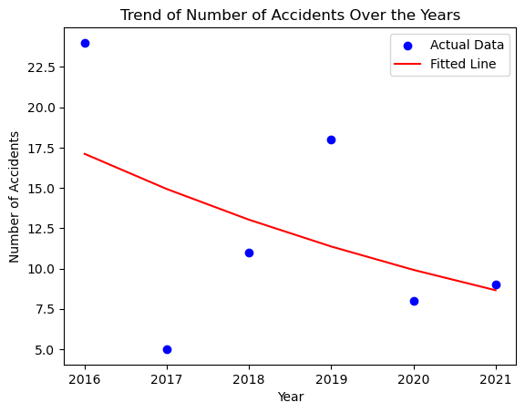

```python
import pandas as pd
import statsmodels.api as sm
import statsmodels.formula.api as smf
import matplotlib.pyplot as plt

# Load the data from the sheet
df = pd.read_excel('Rawalpindi.xlsx', sheet_name='annual distribution')

# Prepare the data for GLM
df['Year'] = df['Year']  # Year as predictor
df['No_of_Accidents'] = df['No of Accidents']  # Number of accidents as outcome

# Fit the GLM model
model = smf.glm('No_of_Accidents ~ Year', data=df, family=sm.families.Poisson()).fit()

# Print the summary of the GLM
print(model.summary())

# Plot the data and the regression line
plt.scatter(df['Year'], df['No_of_Accidents'], color='blue', label='Actual Data')
plt.plot(df['Year'], model.fittedvalues, color='red', label='Fitted Line')
plt.xlabel('Year')
plt.ylabel('Number of Accidents')
plt.title('Trend of Number of Accidents Over the Years')
plt.legend()
plt.show()
```

### Interpretation of GLM Results

#### Overview

The Generalized Linear Model (GLM) results analyze the relationship between the year and the number of accidents using a Poisson regression with a log link function. This model includes 6 observations and a single predictor, `Year`.

#### Key Findings

1. **Intercept**:
   - **Value**: 277.8169
   - **Standard Error**: 138.795
   - **z-Value**: 2.002
   - **P>|z|**: 0.045
   - **95% Confidence Interval**: [5.783, 549.851]

   The intercept represents the expected log count of accidents when the year is zero. This value of 277.8169 is positive, but its interpretation is more abstract in this context, representing a baseline level for the log count of accidents. The p-value (0.045) indicates that the intercept is statistically significant at the 5% level, suggesting that the baseline is significantly different from zero.
2. **Coefficient for Year**:
   - **Value**: -0.1364
   - **Standard Error**: 0.069
   - **z-Value**: -1.983
   - **P>|z|**: 0.047
   - **95% Confidence Interval**: [-0.271, -0.002]

   The coefficient for `Year` is -0.1364. In the context of a Poisson regression with a log link function, this coefficient implies that each additional year is associated with a decrease in the number of accidents by a factor of approximately (e^{-0.1364} \approx 0.873), or about 13% decrease per year.
   - **Statistical Significance**: The p-value for the `Year` coefficient is 0.047, which is below the conventional threshold of 0.05. This indicates that the relationship between the year and the number of accidents is statistically significant.
   - **Confidence Interval**: The 95% confidence interval for the coefficient does not include zero ([-0.271, -0.002]), reinforcing the statistical significance of the negative trend.

#### Conclusion

The analysis shows a significant negative trend in the number of accidents over time. Specifically, the number of accidents is decreasing by about 13% for each additional year. This trend is statistically significant, suggesting a reliable decrease in accidents over the observed period.